# Le vélo à Paris

Comprendre et prévoir le trafic cyclable

2026-11-15

## La question

> Quelle part du trafic cyclable parisien s’explique par le **calendrier**, la **météo** et les **événements**, et peut-on le **prévoir** à quelques jours ?
- Comptages horaires des compteurs vélo de la Ville de Paris, 2019 – 2026
- Météo Paris-Montsouris, jours fériés, vacances scolaires
- Démarche : exploration → décomposition → stationnarité → SARIMA → SARIMAX → concurrents → évaluation

## Une série construite avec soin

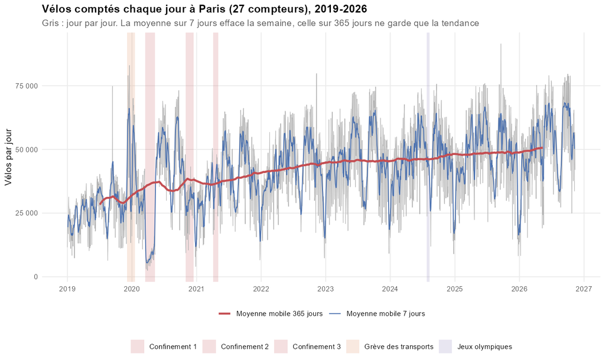

Panel fixe de **27 compteurs** fiables depuis 2019 (sinon fausse tendance) ; 2,7 % de jours de panne détectés et remplacés.

## Deux saisons et un modèle multiplicatif

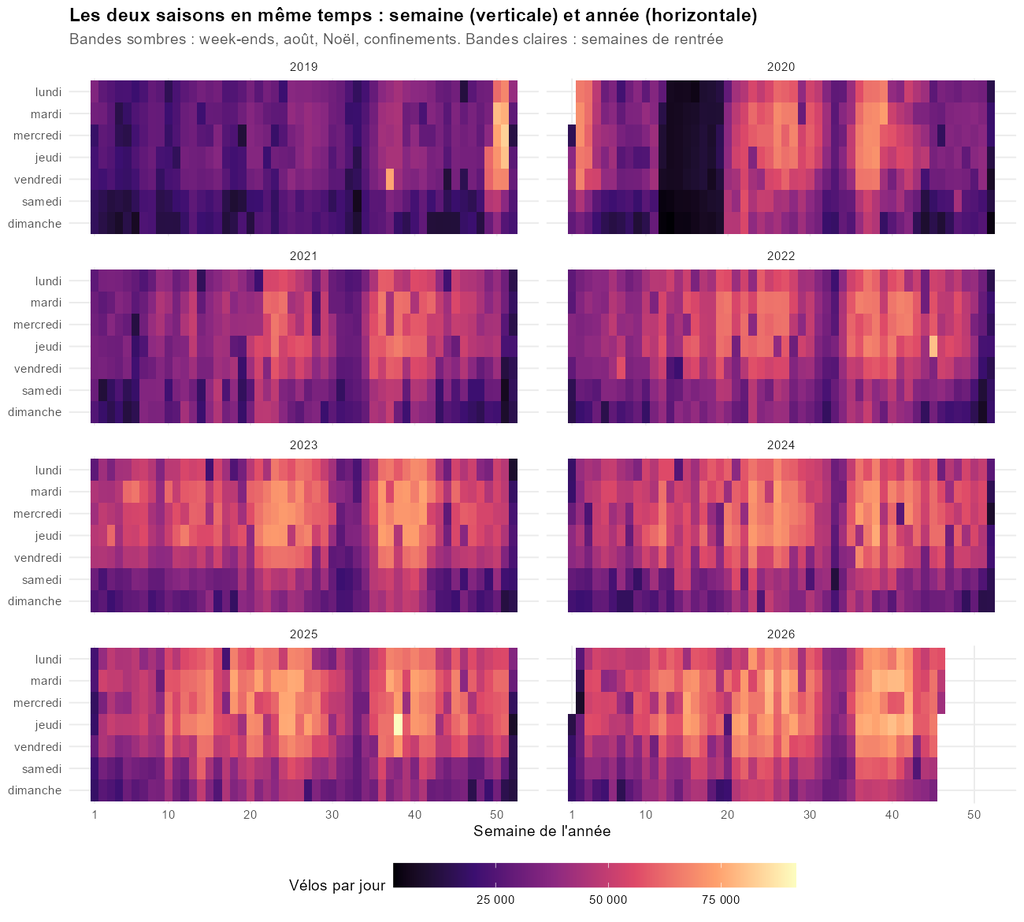

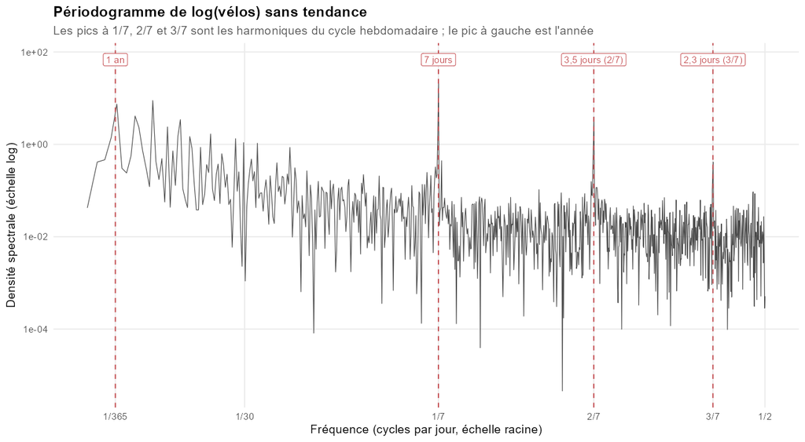

Semaine (pics à 1/7, 2/7, 3/7) et année (1/365) ; écart-type ∝ niveau → **log**.

## Météo et calendrier

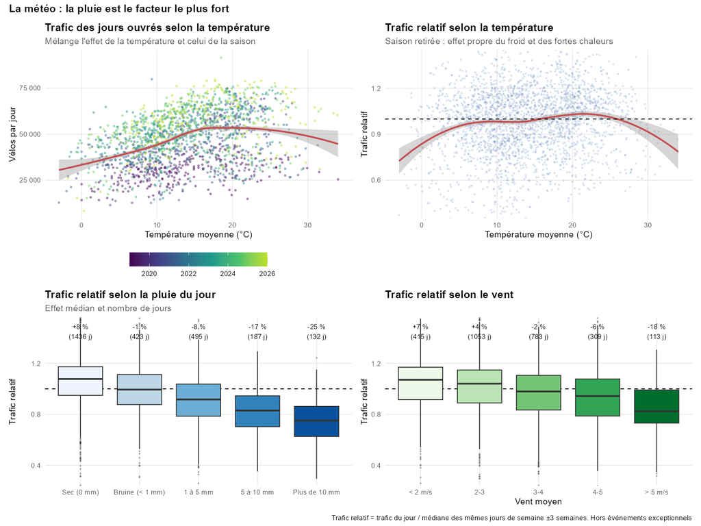

## Décomposition (MSTL, Fourier, Prophet)

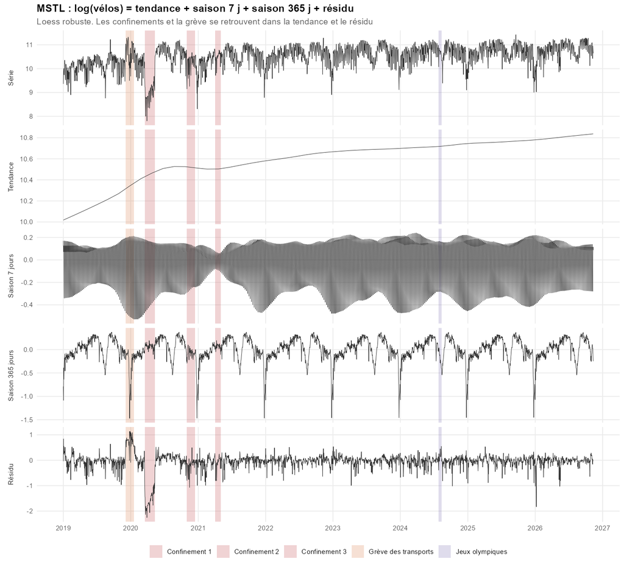

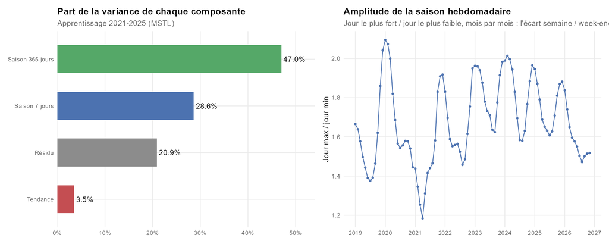

- Moyenne mobile d’ordre 7 : gain nul en 1/7, 2/7, 3/7
- `decompose` (1 saison) ne suffit pas

## Ruptures et événements

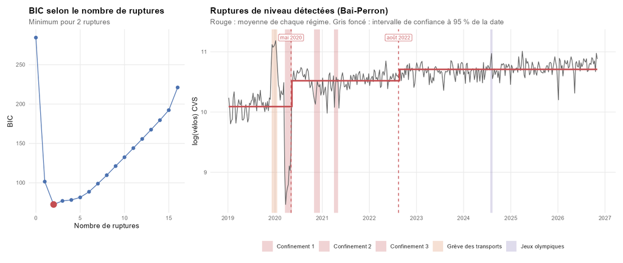

CUSUM : stabilité rejetée sur 2019-2025, **acceptée depuis juin 2021** → période d’apprentissage.

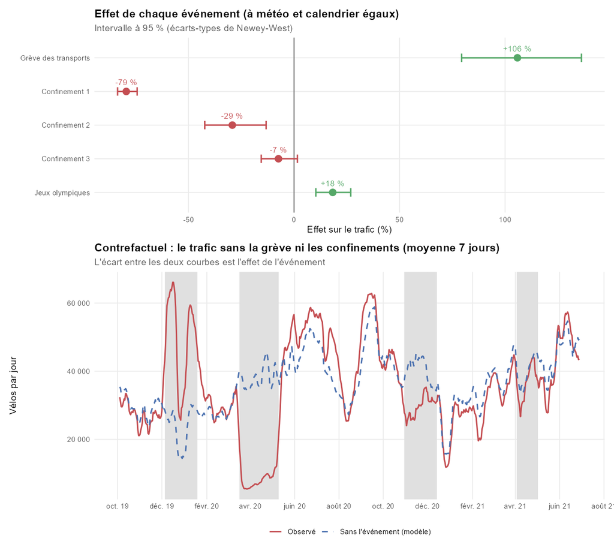

## Stationnarité

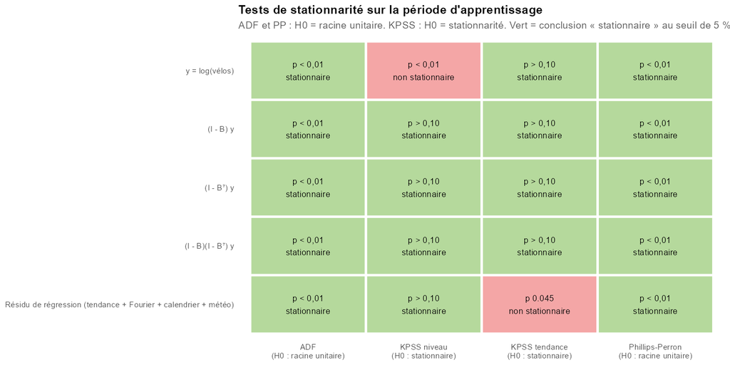

log(vélos) : stationnaire **autour d’une tendance** (d = 0) ; (I − B⁷) supprime la semaine.

## SARIMA(3,0,3)(1,1,2)₇

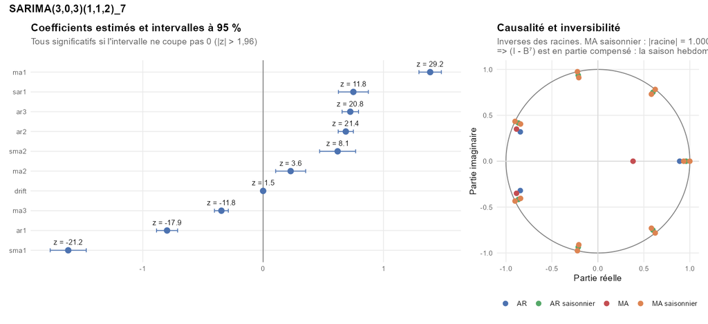

## Diagnostic des résidus

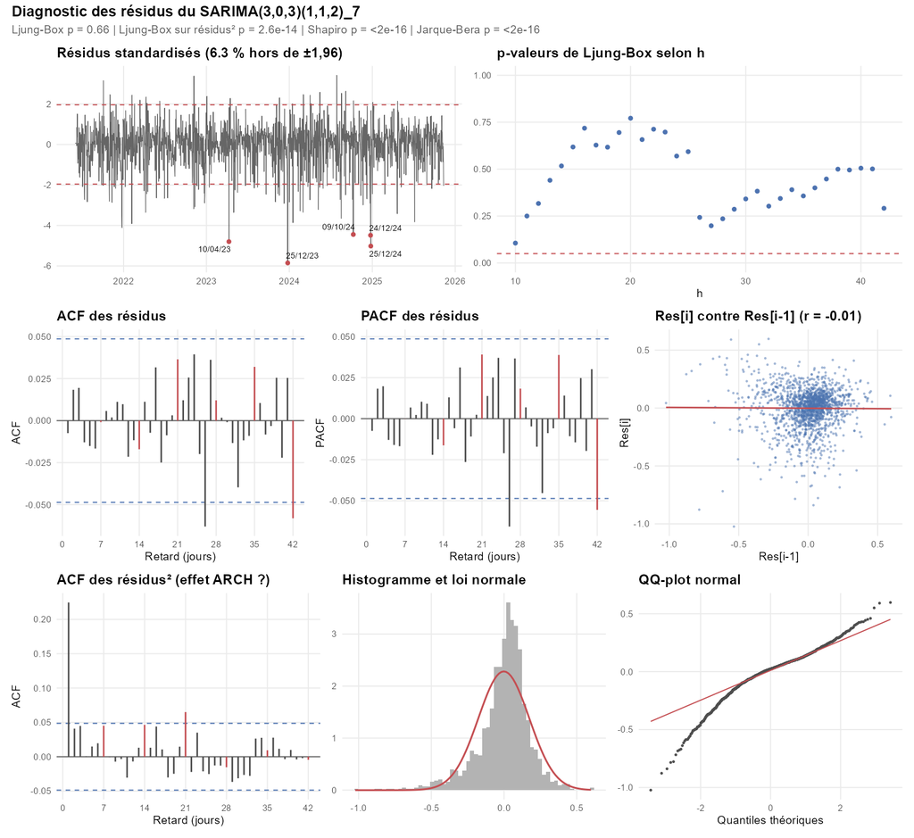

## Compléments de diagnostic

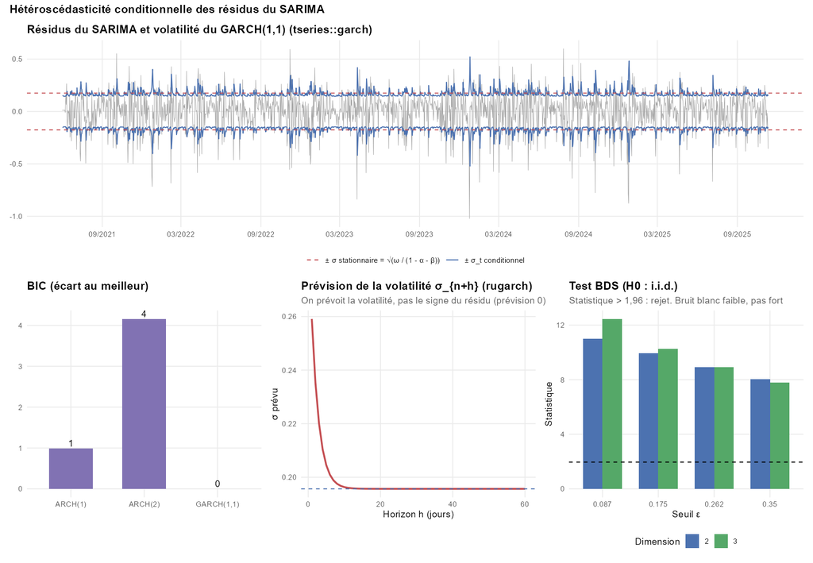

- **Wold** : ψ_k calculés à la main = intervalles de `forecast()`
- **Yule-Walker** : PACF = φ_hh, retrouvée exactement
- **GARCH** : BIC → GARCH(1,1), σ stationnaire = 0,176
- **BDS** rejette i.i.d. : bruit blanc **faible**, pas fort
- **(d, D) = (1, 1)** : racine MA |z| = 1,000 → double sur-différenciation
- Correction **e^{σ²/2}** au retour du log

## SARIMAX : semaine + Fourier + calendrier + météo

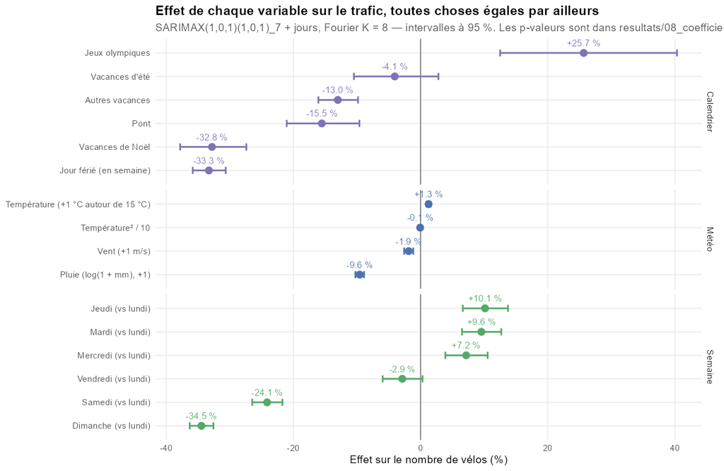

Férié -33 % · Noël -33 % · JO +26 % · +1 °C +1.3 % · erreur à 1 jour **−30 %** par rapport au SARIMA.

## Météo du jour ou de la veille ?

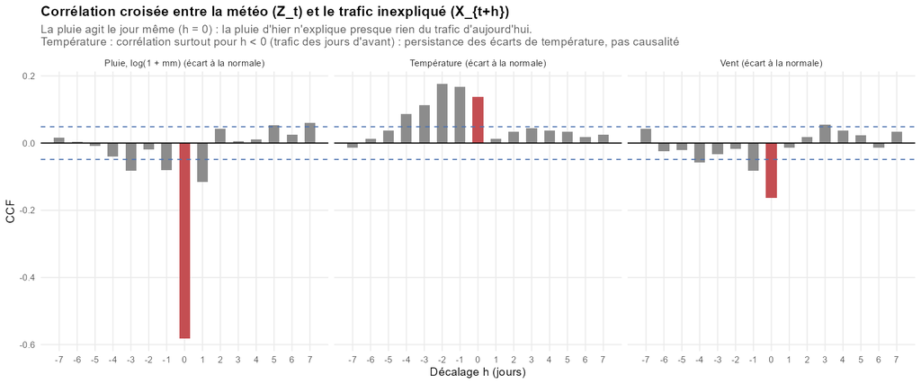

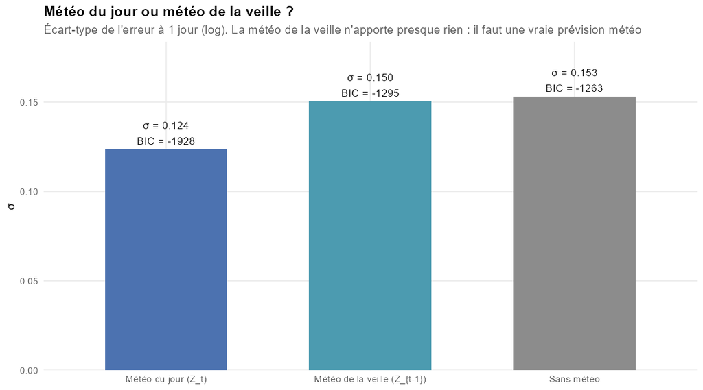

CCF : la pluie agit **le jour même**. Météo de la veille : σ = 0,150 ≈ sans météo (0,153) → il faut une **prévision météo**.

## Réponse : quelle part s’explique par quoi ?

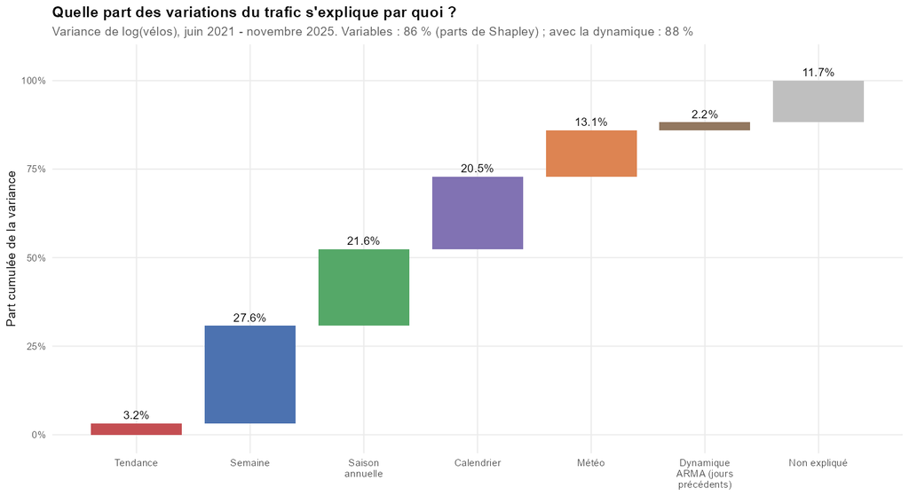

Calendrier (semaine, saison, fériés, vacances) ≈ **70 %**, météo ≈ **13 %**, dynamique ARMA 2 %.

## Quatorze modèles en concurrence

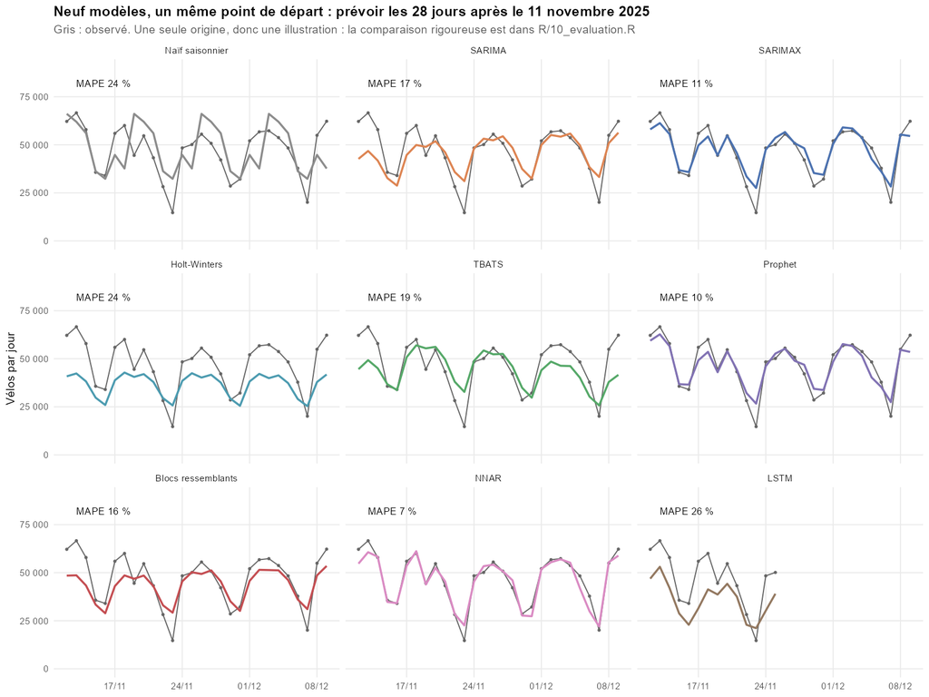

14 modèles : naïf, SARIMA (deux différenciations), SARIMAX (trois scénarios météo), lissages simple / Holt / Holt-Winters, TBATS, Prophet, blocs à noyau calibrés par validation croisée, NNAR, LSTM.

## Évaluation : 352 origines × 14 horizons

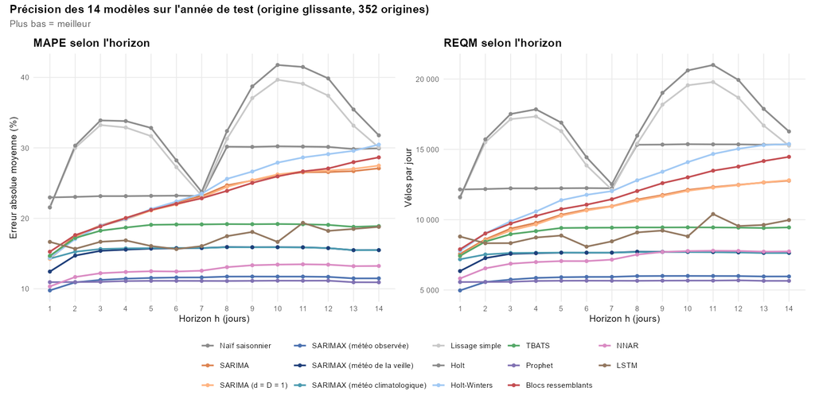

À 1 jour : **SARIMAX** 9,8 % · au-delà : **Prophet** ≈ 11 % · naïf : 23 % à 1 jour.

## La météo, clé de la prévision

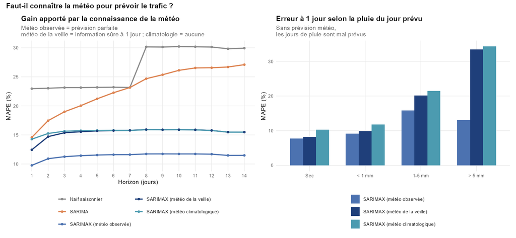

## Prévision : 12 – 25 novembre 2026

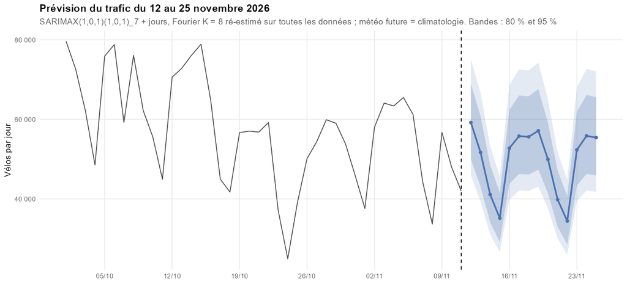

## Conclusion

- Le trafic cyclable parisien est d’abord **rythmé par le calendrier**, puis par la **pluie**
- Démarche Box-Jenkins complète : log, stationnarité autour d’une tendance, SARIMA → racine unité MA saisonnière → semaine déterministe → SARIMAX
- Prévoir à quelques jours : oui, **si l’on dispose d’une prévision météo**
- Limites : queues épaisses, jours exceptionnels (neige, réveillons, journée sans voiture)
- Extension : modèle horaire (saisons 24 h et 168 h)